# Python Bootcamp for Social Media Analytics & Web Mining

### As a student of K-State, you can access over hundreds of data analytics books at no charge through Safari Books Online (http://guides.lib.k-state.edu/az.php?q=safari). Consider the following books for further reading:

- Python Social Media Analytics by Michal Krystyanczuk, Siddhartha Chatterjee
- Mining the Social Web, 3rd Edition by Mikhail Klassen, Matthew A. Russell https://github.com/mikhailklassen/Mining-the-Social-Web-3rd-Edition/tree/master/notebooks
- Web Scraping with Python, 2nd Edition by Ryan Mitchell

### This tutorial will offer some fundamental programming concepts and techniques for Text Analytics using Python. Some materials are adapted from http://www.nltk.org/book_1ed/

### You need to practice the below codes and complete this ipython notebook without any empty cell.

### All HWs will be graded based on three criteria:

1. Mechanical correctness of your python codes: your codes must be accurate
2. Clarity of IPython notebook and organization of outputs:

   The python codes you write must be accompanied with "comments" using # or markdown All outputs must be visible in your IPython notebook. If necessary, explain the outputs using markdown
3. Formatting: "All HWs must contain K-State Honor Code "On my honor, as a student, I have neither given nor received unauthorized aid on this academic work." (See Academic Dishonesty in the course syllabus)

```python
Brian Kassin "On my honor, as a student, I have neither given nor received unauthorized aid on this academic work."
```

# Variables

```python
x = 11              # an integer
f = 2.1526       # a floating real point
name = "Python"    # a string

print(x)
print(f)
print(name)
```

```
11
2.1526
Python
```

```python
feeling = " is great!"    # a string
print(name + feeling)
```

```
Python is great!
```

```python
# print name + x     # can't add a number and a string

print('%s %s' %(name, x))
print('%s%s' %(name, x))
```

```
Python 11
Python11
```

```python
# declare multiple variables (string, integer, float) and display them

a = "great"
b = 1000
c = 25.25
d = "wonderful"

print(a, b, c)
```

```
great 1000 25.25
```

```python
# concatenate the above variables in different ways ...

print('%s%s' %(a, b))
print(a+d)
```

```
great1000
greatwonderful
```

# IF-statements

https://pythonspot.com/conditional-statements/

```python
sentence = "The cat is brown"
q = "cat"

if q == sentence:
    print('equal')
else:
    print('not equal')
```

```
not equal
```

Operator Relationship < less than <= less than or equal to == equal to (note this is two "=" signs, not one) != not equal to > greater than >= greater than or equal to http://www.nltk.org/book_1ed/ch01.html

```python
word = 'cat'
if len(word) < 5:
    print('word length is less than 5')
else:
    print('nothing')
```

```
word length is less than 5
```

```python
# create a if statement testing the length of two different sentences
# display the longer sentence

a = "hello world"
b = "I love kstate"

if len(a) < len(b):
    print(b)
```

```
I love kstate
```

```python
# create a if statement testing two numbers
# display the higher number

a = 5
b = 8

if a < b:
    print(b)
```

```
8
```

# Loop

- Iterate same process (e.g., printing, appending, natural language processing)

```python
a = ['Mary', 'had', 'a', 'little', 'lamb']

for i in a:
    print(i)
```

```
Mary
had
a
little
lamb
```

```python
a = ['Mary', 'had', 'a', 'little', 'lamb']

for i in a:
    print(i + ', ' + "You're great!")
```

```
Mary, You're great!
had, You're great!
a, You're great!
little, You're great!
lamb, You're great!
```

```python
for i in range(1,5):
    print(i)
```

```
1
2
3
4
```

```python
for i in range(1,5):
    print("I love you!")
```

```
I love you!
I love you!
I love you!
I love you!
```

```python
# You can include Youtube video in Ipython notebook
from IPython.display import YouTubeVideo
YouTubeVideo('k0xgjUhEG3U')
```

[video not shown]

```python
# create a looping statement (5 loops)
# but I would like to see a mixture of numbers ans strings

a = 5
b = "brian is cool"

for i in range(0,5):
    print('%s %s' %(b, a))
```

```
brian is cool 5
brian is cool 5
brian is cool 5
brian is cool 5
brian is cool 5
```

```python
# create a looping statement (10 loops)
# but I would like to see the loop number and a sentence in each loop

a = 5
b = "brian is cool"

for i in range(0,10):
    print(i)
    print('%s' %(b))
```

```
0
brian is cool
1
brian is cool
2
brian is cool
3
brian is cool
4
brian is cool
5
brian is cool
6
brian is cool
7
brian is cool
8
brian is cool
9
brian is cool
```

## We'll mostly deal with text data.

## Text data are likely in one of the following formats:

- String
- Lists
- Dictionary

# Strings

```python
x = 'Python'
y = 'is'
z = 'so wonderful!'

sum = x + y + z

print(sum)
print(x + ' ' + y + ' ' + z)    # print concatenated string.
print(x + '   ' + y + '   ' + z)   # print concatenated string.
print(len(z))  # number of characters
```

```
Pythonisso wonderful!
Python is so wonderful!
Python   is   so wonderful!
13
```

```python
# the data inside doublequotes are considered string

data = "Hello Python"
print(data)       # prints whole string

#indexing
print(data[0:2])  # prints "He"
print(data[6:])   # prints "Python"

# replace string
print(data.replace('Hello','Thanks')) # print a string with a replaced word

#split
print(data.split())
```

```
Hello Python
He
Python
Thanks Python
['Hello', 'Python']
```

```python
# create a stringe variable containing a sentence
# print the last word only

a = "brian is cool"

print(a[9:])
```

```
cool
```

```python
# replace one of the words with "I am happy"

a = "brian is cool"

print(a.replace('cool', 'I am happy'))
```

```
brian is I am happy
```

# Lists

https://pythonspot.com/python-lists/

- each value is assigned into an **index** or a **position** ... this is like **address** ... **the first index is zero; the second index is one**
- the data are inside [ ] or [ [ ] ]

```python
# this is a list of data in two columns. The first column or index contains resturant reviews
# the second column or index says whether it is positive or negative
train = [
     ('I love this sandwich.', 'pos'),
     ('this is an amazing place!', 'pos'),
     ('I feel very good about these beers.', 'pos'),
     ('this is my best work.', 'pos'),
     ("what an awesome view", 'pos'),
     ('I do not like this restaurant', 'neg'),
     ('I am tired of this stuff.', 'neg'),
     ("I can't deal with this", 'neg'),
     ('he is my sworn enemy!', 'neg'),
     ('my boss is horrible.', 'neg')
    ]

print(train)
```

```
[('I love this sandwich.', 'pos'), ('this is an amazing place!', 'pos'), ('I feel very good about these beers.', 'pos'), ('this is my best work.', 'pos'), ('what an awesome view', 'pos'), ('I do not like this restaurant', 'neg'), ('I am tired of this stuff.', 'neg'), ("I can't deal with this", 'neg'…
```

```python
# Looping
for i in train:
    print(i)
```

```
('I love this sandwich.', 'pos')
('this is an amazing place!', 'pos')
('I feel very good about these beers.', 'pos')
('this is my best work.', 'pos')
('what an awesome view', 'pos')
('I do not like this restaurant', 'neg')
('I am tired of this stuff.', 'neg')
("I can't deal with this", 'neg')
('he is my sworn enemy!', 'neg')
('my boss is horrible.', 'neg')
```

```python
for i in train:
    print(i[0])                 # i[0] refers to the data in the first column
```

```
I love this sandwich.
this is an amazing place!
I feel very good about these beers.
this is my best work.
what an awesome view
I do not like this restaurant
I am tired of this stuff.
I can't deal with this
he is my sworn enemy!
my boss is horrible.
```

```python
for i in train:
    print(i[1])      # i[0] refers to the data in the second column
```

```
pos
pos
pos
pos
pos
neg
neg
neg
neg
neg
```

```python
for i in train:
    print(i[0], i[1])
```

```
I love this sandwich. pos
this is an amazing place! pos
I feel very good about these beers. pos
this is my best work. pos
what an awesome view pos
I do not like this restaurant neg
I am tired of this stuff. neg
I can't deal with this neg
he is my sworn enemy! neg
my boss is horrible. neg
```

```python
# # saving the first column's data using a variable (review)
review = [i[0] for i in train]
review
```

```
['I love this sandwich.',
 'this is an amazing place!',
 'I feel very good about these beers.',
 'this is my best work.',
 'what an awesome view',
 'I do not like this restaurant',
 'I am tired of this stuff.',
 "I can't deal with this",
 'he is my sworn enemy!',
 'my boss is horrible.']
```

```python
review[1:5]
```

```
['this is an amazing place!',
 'I feel very good about these beers.',
 'this is my best work.',
 'what an awesome view']
```

```python
# saving the second column's data using a variable (rating)
rating = [i[1] for i in train]
rating
```

```
['pos', 'pos', 'pos', 'pos', 'pos', 'neg', 'neg', 'neg', 'neg', 'neg']
```

```python
rating[0:10]
```

```
['pos', 'pos', 'pos', 'pos', 'pos', 'neg', 'neg', 'neg', 'neg', 'neg']
```

```python
# we can concatenate review and rating and save the data using a variable (customer_review)
customer_review = list(zip(review, rating))
customer_review
```

```
[('I love this sandwich.', 'pos'),
 ('this is an amazing place!', 'pos'),
 ('I feel very good about these beers.', 'pos'),
 ('this is my best work.', 'pos'),
 ('what an awesome view', 'pos'),
 ('I do not like this restaurant', 'neg'),
 ('I am tired of this stuff.', 'neg'),
 ("I can't deal with this", 'neg'),
 ('he is my sworn enemy!', 'neg'),
 ('my boss is horrible.', 'neg')]
```

```python
# print the first three rows
customer_review[0:3]
```

```
[('I love this sandwich.', 'pos'),
 ('this is an amazing place!', 'pos'),
 ('I feel very good about these beers.', 'pos')]
```

```python
# print everything from the second row
customer_review[1:]
```

```
[('this is an amazing place!', 'pos'),
 ('I feel very good about these beers.', 'pos'),
 ('this is my best work.', 'pos'),
 ('what an awesome view', 'pos'),
 ('I do not like this restaurant', 'neg'),
 ('I am tired of this stuff.', 'neg'),
 ("I can't deal with this", 'neg'),
 ('he is my sworn enemy!', 'neg'),
 ('my boss is horrible.', 'neg')]
```

```python
# how many rows in the data (customer_review)
len(customer_review)
```

```
10
```

```python
# here is a new review
review11 = [('the food is great.', 'pos')]
```

```python
# append
customer_review_updated = customer_review + review11
customer_review_updated
```

```
[('I love this sandwich.', 'pos'),
 ('this is an amazing place!', 'pos'),
 ('I feel very good about these beers.', 'pos'),
 ('this is my best work.', 'pos'),
 ('what an awesome view', 'pos'),
 ('I do not like this restaurant', 'neg'),
 ('I am tired of this stuff.', 'neg'),
 ("I can't deal with this", 'neg'),
 ('he is my sworn enemy!', 'neg'),
 ('my boss is horrible.', 'neg'),
 ('the food is great.', 'pos')]
```

```python
len(customer_review_updated)
```

```
11
```

```python
# now, it is your turn to practice. below is a sample data.
test = [
    ('the beer was good.', 'pos'),
     ('I do not enjoy my job', 'neg'),
     ("I ain't feeling dandy today.", 'neg'),
     ("I feel amazing!", 'pos'),
     ('Gary is a friend of mine.', 'pos'),
     ("I can't believe I'm doing this.", 'neg')
 ]
```

```python
# print the data using a loop statement

for i in test:
    print(i)
```

```
('the beer was good.', 'pos')
('I do not enjoy my job', 'neg')
("I ain't feeling dandy today.", 'neg')
('I feel amazing!', 'pos')
('Gary is a friend of mine.', 'pos')
("I can't believe I'm doing this.", 'neg')
```

```python
# print the first column only

for i in test:
    print(i[0])
```

```
the beer was good.
I do not enjoy my job
I ain't feeling dandy today.
I feel amazing!
Gary is a friend of mine.
I can't believe I'm doing this.
```

```python
# print the second column only

for i in test:
    print(i[1])
```

```
pos
neg
neg
pos
pos
neg
```

```python
# count how many?

test1 = [i for i in test]
len(test1)
```

```
6
```

## Dictionaries

Social media are in the form of dictionaries (usually in JSON file)

Visit https://dev.twitter.com/rest/reference/get/search/tweets to view a sample Twitter data in JSON format

More JSON examples https://www.sitepoint.com/10-example-json-files/

```python
#https://textblob.readthedocs.org/en/dev/classifiers.html#classifying-text

data = [
    {"text": "I love this sandwich.", "label": "pos"},
    {"text": "This is an amazing place!", "label": "pos"},
    {"text": "I do not like this restaurant", "label": "neg"}
]

#text, label are like column names
```

```python
data
```

```
[{'text': 'I love this sandwich.', 'label': 'pos'},
 {'text': 'This is an amazing place!', 'label': 'pos'},
 {'text': 'I do not like this restaurant', 'label': 'neg'}]
```

```python
for i in data:
    print(i)
```

```
{'text': 'I love this sandwich.', 'label': 'pos'}
{'text': 'This is an amazing place!', 'label': 'pos'}
{'text': 'I do not like this restaurant', 'label': 'neg'}
```

```python
for i in data:
    print(i['text'])
```

```
I love this sandwich.
This is an amazing place!
I do not like this restaurant
```

```python
for i in data:
    print(i['label'])
```

```
pos
pos
neg
```

```python
for i in data:
    print(i['text'], i['label'])
```

```
I love this sandwich. pos
This is an amazing place! pos
I do not like this restaurant neg
```

```python
text = [i['text'] for i in data]
text
```

```
['I love this sandwich.',
 'This is an amazing place!',
 'I do not like this restaurant']
```

```python
label = [i['label'] for i in data]
label
```

```
['pos', 'pos', 'neg']
```

```python
finaldata = list(zip(text, label))
finaldata
```

```
[('I love this sandwich.', 'pos'),
 ('This is an amazing place!', 'pos'),
 ('I do not like this restaurant', 'neg')]
```

```python
# https://adobe.github.io/Spry/samples/data_region/JSONDataSetSample.html#Example1
data = [
        { "id": "1001", "type": "Regular" },
        { "id": "1002", "type": "Chocolate" },
        { "id": "1003", "type": "Blueberry" },
        { "id": "1004", "type": "Devil's Food" },
        { "id": "5002", "type": "Glazed" },
        { "id": "5005", "type": "Sugar" },
        { "id": "5007", "type": "Powdered Sugar" },
        { "id": "5006", "type": "Chocolate with Sprinkles" },
        { "id": "5003", "type": "Chocolate" },
        { "id": "5004", "type": "Maple" }
        ]
```

```python
# print id and type

for i in data:
    print(i['id'], i['type'])
```

```
1001 Regular
1002 Chocolate
1003 Blueberry
1004 Devil's Food
5002 Glazed
5005 Sugar
5007 Powdered Sugar
5006 Chocolate with Sprinkles
5003 Chocolate
5004 Maple
```

```python
# save id using a new variable

a = [i['id'] for i in data]
a
```

```
['1001',
 '1002',
 '1003',
 '1004',
 '5002',
 '5005',
 '5007',
 '5006',
 '5003',
 '5004']
```

```python
# save type using another new variable

b = [i['type'] for i in data]
b
```

```
['Regular',
 'Chocolate',
 'Blueberry',
 "Devil's Food",
 'Glazed',
 'Sugar',
 'Powdered Sugar',
 'Chocolate with Sprinkles',
 'Chocolate',
 'Maple']
```

```python
# combine the values from id variable and type variable
# display the outcome

x = list(zip(a, b))
x
```

```
[('1001', 'Regular'),
 ('1002', 'Chocolate'),
 ('1003', 'Blueberry'),
 ('1004', "Devil's Food"),
 ('5002', 'Glazed'),
 ('5005', 'Sugar'),
 ('5007', 'Powdered Sugar'),
 ('5006', 'Chocolate with Sprinkles'),
 ('5003', 'Chocolate'),
 ('5004', 'Maple')]
```

# Converting list to string

For text mining, we often convert the format of the data from list to string

```python
# data in list
tokens = ['After', 'all', 'is', 'said', 'and', 'done', 'more', 'is', 'said', 'than', 'done']
```

```python
len(tokens)
```

```
11
```

11 words in the list

```python
#str

tokens_modified = str(tokens)
tokens_modified
```

```
"['After', 'all', 'is', 'said', 'and', 'done', 'more', 'is', 'said', 'than', 'done']"
```

see "doublequotes", representing that the data are in string format

```python
len(tokens_modified)
```

```
83
```

83 characters (including letters, whitespace, quotations) inside the bracket

```python
# create a list and convert to string. Count the number of characters ...

tokens1 = ['After', 'all', 'is', 'lol', 'and', 'row', 'so', 'is', 'said', 'than', 'done']

a = str(tokens1)
print(len(a))
print(a)
```

```
79
['After', 'all', 'is', 'lol', 'and', 'row', 'so', 'is', 'said', 'than', 'done']
```

```python
# explain the difference between list and string

data is much easier to manipulate when in string format.

data is counted as individual words in list format and counted as indiviual characters in string format
```

## Looping & IF statements

Some Word Comparison Operators Function Meaning s.startswith(t) test if s starts with t s.endswith(t) test if s ends with t t in s test if t is contained inside s s.islower() test if all cased characters in s are lowercase s.isupper() test if all cased characters in s are uppercase s.isalpha() test if all characters in s are alphabetic s.isalnum() test if all characters in s are alphanumeric s.isdigit() test if all characters in s are digits s.istitle() test if s is titlecased (all words in s have have initial capitals) http://www.nltk.org/book_1ed/ch01.html

```python
sent1 = ['Tell', 'kevin3', '?', 'hEllo', 'music is wonderful']

for i in sent1:
    if len(i) > 2:
        print(i)
```

```
Tell
kevin3
hEllo
music is wonderful
```

```python
for token in sent1:
    if token.islower():               #islower() tests if a word is lowercase or not
        print(token, 'is a lowercase word')
    elif token.isalnum():             #isalnum() tests if a word is alphanumeric
        print(token, 'is a alphanumeric word')
    else:
        print(token, 'is non-alphanumeric word')
```

```
Tell is a alphanumeric word
kevin3 is a lowercase word
? is non-alphanumeric word
hEllo is a alphanumeric word
music is wonderful is a lowercase word
```

```python
# how many lower case words?
for token in sent1:
    if token.islower():
        print(token)
```

```
kevin3
music is wonderful
```

```python
# below is same as the above ... but, here two sentences are saved in a variable (lowercase_words)
lowercase_words = [ token for token in sent1 if token.islower() ]
print(lowercase_words)
```

```
['kevin3', 'music is wonderful']
```

```python
len(lowercase_words)
```

```
2
```

```python
# print only the positive reviews

test = [
    ('the beer was good.', 'pos'),
     ('I do not enjoy my job', 'neg'),
     ("I ain't feeling dandy today.", 'neg'),
     ("I feel amazing!", 'pos'),
     ('Gary is a friend of mine.', 'pos'),
     ("I can't believe I'm doing this.", 'neg')
 ]

for i in test:
    if i[1] == 'pos':
        print(i)
```

```
('the beer was good.', 'pos')
('I feel amazing!', 'pos')
('Gary is a friend of mine.', 'pos')
```

```python
# count how many negative reviews? show the answer using python codes

for i in test:
    if i[1] == 'neg':
        print(i)
```

```
('I do not enjoy my job', 'neg')
("I ain't feeling dandy today.", 'neg')
("I can't believe I'm doing this.", 'neg')
```

```python
neg = [i for i in test if i[1] == 'neg']
neg
```

```
[('I do not enjoy my job', 'neg'),
 ("I ain't feeling dandy today.", 'neg'),
 ("I can't believe I'm doing this.", 'neg')]
```

```python
print(len(neg))
```

```
3
```

```python
# count how many positive reviews? show the answer using python codes

for i in test:
    if i[1] == 'pos':
        print (i)
```

```
('the beer was good.', 'pos')
('I feel amazing!', 'pos')
('Gary is a friend of mine.', 'pos')
```

```python
pos = [i for i in test if i[1] == 'pos']
len(pos)
```

```
3
```

```python
# test if the product is perceived positive or negative based on the number of positiv and negative reviews
# if positive reviews > negative reviews, then the product is positive and vice versa.

if len(neg) < len(pos):
    print('our product is good')
elif len(neg) > len(pos):
    print('our product is bad')
else:
    print('it is okay')
```

```
it is okay
```

# Importing Python Packages

In Python, we use Python packages. Packages are modules or add-ins. For example, if you want to read and/or save a text file, you need to import the relevant python package(s).

**import csv**

If you want to analyze texts, you would import the relevant python package(s) first.

**import nltk**

```python
# import nltk, which is a python package for natural language processing
import nltk

# to read and/or save text files or csv files, import csv
import csv

# to read and handle data like Excel
import pandas as pd

# to use data visualization
import matplotlib.pyplot as plt
%matplotlib inline
```

# Install Python Packages

If you receive an error message when trying to import python packages such as nltk, it means that the package is not installed in your pc. Here is the installation instruction.

- start a command prompt (in Windows) or a terminal (in Mac)
- type **pip install nameofpackage** (for example, **pip install nltk**)

**Note: some python packages (e.g., csv) are alredy installed in your machine when you install Anaconda**

After this installation, you can do this:

- **import nltk**

```python
# install a popular python called "seaborn" (for advanced statistical data visualization)
# for this, you need to open a command prompt or a terminal

!pip install seaborn
#!pip install twippy
```

# Read & Write File

## Read data as list from file

```python
import csv  # if you have already imported this python package earlier, no need to repeat this

r = csv.reader(open('data/tips.csv', 'r'))

# printing the entire data as lists
for i in r:
    print(i)
```

```
['16.27', '2.5', 'Female', 'Yes', 'Fri', 'Lunch', '2']
['10.09', '2', 'Female', 'Yes', 'Fri', 'Lunch', '2']
['20.45', '3', 'Male', 'No', 'Sat', 'Dinner', '4']
['13.28', '2.72', 'Male', 'No', 'Sat', 'Dinner', '2']
['22.12', '2.88', 'Female', 'Yes', 'Sat', 'Dinner', '2']
['24.01', '2', 'Male', 'Yes', 'Sat', 'Dinner', '4']
['15.69', '3', 'Male', 'Yes', 'Sat', 'Dinner', '3']
['11.61', '3.39', 'Male', 'No', 'Sat', 'Dinner', '2']
['10.77', '1.47', 'Male', 'No', 'Sat', 'Dinner', '2']
['15.53', '3', 'Male', 'Yes', 'Sat', 'Dinner', '2']
['10.07', '1.25', 'Male', 'No', 'Sat', 'Dinner', '2']
['12.6', '1', 'Male', 'Yes', 'Sat', 'Dinner', '2']
['32.83', '1.17', 'Male', 'Yes', 'Sat', 'Dinner', '2']
['35.83', '4.67', 'Female', 'No', 'Sat', 'Dinner', '3']
['29.03', '5.92', 'Male', 'No', 'Sat', 'Dinner', '3']
['27.18', '2', 'Female', 'Yes', 'Sat', 'Dinner', '2']
['22.67', '2', 'Male', 'Yes', 'Sat', 'Dinner', '2']
['17.82', '1.75', 'Male', 'No', 'Sat', 'Dinner', '2']
['18.78', '3', 'Female', 'No', 'Thur', 'Dinner', '2']
```

```python
# save the data in a variable

data = []     # declare an empty list to store a large volume of data
r = csv.reader(open('data/tips.csv', 'r'))
for i in r:
    data.append(i)
data
```

```
[['16.27', '2.5', 'Female', 'Yes', 'Fri', 'Lunch', '2'],
 ['10.09', '2', 'Female', 'Yes', 'Fri', 'Lunch', '2'],
 ['20.45', '3', 'Male', 'No', 'Sat', 'Dinner', '4'],
 ['13.28', '2.72', 'Male', 'No', 'Sat', 'Dinner', '2'],
 ['22.12', '2.88', 'Female', 'Yes', 'Sat', 'Dinner', '2'],
 ['24.01', '2', 'Male', 'Yes', 'Sat', 'Dinner', '4'],
 ['15.69', '3', 'Male', 'Yes', 'Sat', 'Dinner', '3'],
 ['11.61', '3.39', 'Male', 'No', 'Sat', 'Dinner', '2'],
 ['10.77', '1.47', 'Male', 'No', 'Sat', 'Dinner', '2'],
 ['15.53', '3', 'Male', 'Yes', 'Sat', 'Dinner', '2'],
 ['10.07', '1.25', 'Male', 'No', 'Sat', 'Dinner', '2'],
 ['12.6', '1', 'Male', 'Yes', 'Sat', 'Dinner', '2'],
 ['32.83', '1.17', 'Male', 'Yes', 'Sat', 'Dinner', '2'],
 ['35.83', '4.67', 'Female', 'No', 'Sat', 'Dinner', '3'],
 ['29.03', '5.92', 'Male', 'No', 'Sat', 'Dinner', '3'],
 ['27.18', '2', 'Female', 'Yes', 'Sat', 'Dinner', '2'],
 ['22.67', '2', 'Male', 'Yes', 'Sat', 'Dinner', '2'],
 ['17.82', '1.75', 'Male', 'No', 'Sat', 'Dinner', '2'],
 ['18.78', '3', 'Female', 'No', 'Thur', 'Dinner', '2']]
```

### Python List is very flexible in terms of proceessing text data

```python
# an empty list
gender = []
r = csv.reader(open('data/tips.csv', 'r'))
for row in r:
    #2 is an index or a position for the data in the third column
    gender.append(row[2])
gender
```

```
['Female',
 'Female',
 'Male',
 'Male',
 'Female',
 'Male',
 'Male',
 'Male',
 'Male',
 'Male',
 'Male',
 'Male',
 'Male',
 'Female',
 'Male',
 'Female',
 'Male',
 'Male',
 'Female']
```

```python
r = csv.reader(open('data/tips.csv', 'r'))
for row in r:
    total = row[0]
    tip = row[1]
    gender = row[2]
    print(total, tip, gender)
```

```
16.27 2.5 Female
10.09 2 Female
20.45 3 Male
13.28 2.72 Male
22.12 2.88 Female
24.01 2 Male
15.69 3 Male
11.61 3.39 Male
10.77 1.47 Male
15.53 3 Male
10.07 1.25 Male
12.6 1 Male
32.83 1.17 Male
35.83 4.67 Female
29.03 5.92 Male
27.18 2 Female
22.67 2 Male
17.82 1.75 Male
18.78 3 Female
```

```python
r = csv.reader(open('data/tips.csv', 'r'))
data = []
for row in r:
    total = row[0]
    tip = row[1]
    gender = row[2]
    data.append([total, tip, gender])
data
```

```
[['16.27', '2.5', 'Female'],
 ['10.09', '2', 'Female'],
 ['20.45', '3', 'Male'],
 ['13.28', '2.72', 'Male'],
 ['22.12', '2.88', 'Female'],
 ['24.01', '2', 'Male'],
 ['15.69', '3', 'Male'],
 ['11.61', '3.39', 'Male'],
 ['10.77', '1.47', 'Male'],
 ['15.53', '3', 'Male'],
 ['10.07', '1.25', 'Male'],
 ['12.6', '1', 'Male'],
 ['32.83', '1.17', 'Male'],
 ['35.83', '4.67', 'Female'],
 ['29.03', '5.92', 'Male'],
 ['27.18', '2', 'Female'],
 ['22.67', '2', 'Male'],
 ['17.82', '1.75', 'Male'],
 ['18.78', '3', 'Female']]
```

```python
# saving the data
outputfile= open('data/output_columns.csv','w')
w = csv.writer(outputfile)
for row in data:
    w.writerow(row)
outputfile.close()
```

### Read a csv file and create a new csv file

```python
#to read a csv file
openfile = open('data/tips.csv', 'r')
r = csv.reader(openfile)

#to write or create a new csv file
outputfile= open('data/output_tipspartialinfo.csv','w')
w = csv.writer(outputfile)

#saving partial data in a new csv file
for row in r:
    # first column in the list
    total = row[0]
    # second column in the list
    tip = row[1]
    w.writerow([total, tip])

openfile.close()
outputfile.close()
```

## Pandas: read the data like an Excel worksheet

```python
# Read method in Pandas
import pandas as pd

#data = pd.read_csv('data/output_texts1.csv')
data = pd.read_csv('data/output_texts1.csv', header=None)
data

# the first row becomes the column name by default ... header=None creates a default column name "0"
```

|  | 0 |
| --- | --- |
| 0 | kevin |
| 1 | john is awesome |
| 2 | I love NY! |

```python
#create a csv file with the data r
import pandas as pd

data.to_csv('data/output_texts2.csv')
```

```python
#using Pandas: Pandas format the data more like an Excel workshett (this is technically called a two dimentional array)
#data = pd.read_csv('data/tips.csv')
data = pd.read_csv('data/tips.csv', header=None)
data
```

|  | 0 | 1 | 2 | 3 | 4 | 5 | 6 |
| --- | --- | --- | --- | --- | --- | --- | --- |
| 0 | 16.27 | 2.50 | Female | Yes | Fri | Lunch | 2 |
| 1 | 10.09 | 2.00 | Female | Yes | Fri | Lunch | 2 |
| 2 | 20.45 | 3.00 | Male | No | Sat | Dinner | 4 |
| 3 | 13.28 | 2.72 | Male | No | Sat | Dinner | 2 |
| 4 | 22.12 | 2.88 | Female | Yes | Sat | Dinner | 2 |
| 5 | 24.01 | 2.00 | Male | Yes | Sat | Dinner | 4 |
| 6 | 15.69 | 3.00 | Male | Yes | Sat | Dinner | 3 |
| 7 | 11.61 | 3.39 | Male | No | Sat | Dinner | 2 |
| 8 | 10.77 | 1.47 | Male | No | Sat | Dinner | 2 |
| 9 | 15.53 | 3.00 | Male | Yes | Sat | Dinner | 2 |
| 10 | 10.07 | 1.25 | Male | No | Sat | Dinner | 2 |
| 11 | 12.60 | 1.00 | Male | Yes | Sat | Dinner | 2 |
| 12 | 32.83 | 1.17 | Male | Yes | Sat | Dinner | 2 |
| 13 | 35.83 | 4.67 | Female | No | Sat | Dinner | 3 |
| 14 | 29.03 | 5.92 | Male | No | Sat | Dinner | 3 |
| 15 | 27.18 | 2.00 | Female | Yes | Sat | Dinner | 2 |
| 16 | 22.67 | 2.00 | Male | Yes | Sat | Dinner | 2 |
| 17 | 17.82 | 1.75 | Male | No | Sat | Dinner | 2 |
| 18 | 18.78 | 3.00 | Female | No | Thur | Dinner | 2 |

### covert list to dataframe

```python
#data in list
data = [['apple', '34', 'fruit'],
 ['pear', '3', 'fruit'],
 ['lettuce', '4', 'veg'],
 ['potato', '15', 'veg'],
 ['mango', '22', 'fruit']]
```

```python
for i in data:
    print(i)
```

```
['apple', '34', 'fruit']
['pear', '3', 'fruit']
['lettuce', '4', 'veg']
['potato', '15', 'veg']
['mango', '22', 'fruit']
```

```python
# to data frame (Excel like)
df = pd.DataFrame(data)
df
#looks like a worksheet in Excel
```

|  | 0 | 1 | 2 |
| --- | --- | --- | --- |
| 0 | apple | 34 | fruit |
| 1 | pear | 3 | fruit |
| 2 | lettuce | 4 | veg |
| 3 | potato | 15 | veg |
| 4 | mango | 22 | fruit |

```python
df = df.rename(columns={0:'fruit', 1:'count', 2:'type'})
df
```

|  | fruit | count | type |
| --- | --- | --- | --- |
| 0 | apple | 34 | fruit |
| 1 | pear | 3 | fruit |
| 2 | lettuce | 4 | veg |
| 3 | potato | 15 | veg |
| 4 | mango | 22 | fruit |

```python
#basic statistics
df.describe()
```

|  | fruit | count | type |
| --- | --- | --- | --- |
| count | 5 | 5 | 5 |
| unique | 5 | 5 | 2 |
| top | lettuce | 22 | fruit |
| freq | 1 | 1 | 3 |

```python
# descriptive analytics & pivot
df.groupby('type').count()
```

| type | fruit | count |
| --- | --- | --- |
| fruit | 3 | 3 |
| veg | 2 | 2 |

```python
# at this point, you should have a csv file named "output_tipspartialinfo.csv" inside the data folder

# read the data using pandas

import pandas as pd

data = pd.read_csv('data/output_tipspartialinfo.csv', header=None)
data
```

|  | 0 | 1 |
| --- | --- | --- |
| 0 | 16.27 | 2.50 |
| 1 | 10.09 | 2.00 |
| 2 | 20.45 | 3.00 |
| 3 | 13.28 | 2.72 |
| 4 | 22.12 | 2.88 |
| 5 | 24.01 | 2.00 |
| 6 | 15.69 | 3.00 |
| 7 | 11.61 | 3.39 |
| 8 | 10.77 | 1.47 |
| 9 | 15.53 | 3.00 |
| 10 | 10.07 | 1.25 |
| 11 | 12.60 | 1.00 |
| 12 | 32.83 | 1.17 |
| 13 | 35.83 | 4.67 |
| 14 | 29.03 | 5.92 |
| 15 | 27.18 | 2.00 |
| 16 | 22.67 | 2.00 |
| 17 | 17.82 | 1.75 |
| 18 | 18.78 | 3.00 |

```python
# select only one column

data = pd.read_csv('data/output_tipspartialinfo.csv', header=None, usecols = [0])
data
```

|  | 0 |
| --- | --- |
| 0 | 16.27 |
| 1 | 10.09 |
| 2 | 20.45 |
| 3 | 13.28 |
| 4 | 22.12 |
| 5 | 24.01 |
| 6 | 15.69 |
| 7 | 11.61 |
| 8 | 10.77 |
| 9 | 15.53 |
| 10 | 10.07 |
| 11 | 12.60 |
| 12 | 32.83 |
| 13 | 35.83 |
| 14 | 29.03 |
| 15 | 27.18 |
| 16 | 22.67 |
| 17 | 17.82 |
| 18 | 18.78 |

```python
import csv  # if you have already imported this python package earlier, no need to repeat this

r = csv.reader(open('data/output_tipspartialinfo.csv', 'r'))

for i in r:
    print(i)
```

```
['16.27', '2.5']
[]
['10.09', '2']
[]
['20.45', '3']
[]
['13.28', '2.72']
[]
['22.12', '2.88']
[]
['24.01', '2']
[]
['15.69', '3']
[]
['11.61', '3.39']
[]
['10.77', '1.47']
[]
['15.53', '3']
[]
['10.07', '1.25']
[]
['12.6', '1']
[]
['32.83', '1.17']
[]
['35.83', '4.67']
[]
['29.03', '5.92']
[]
['27.18', '2']
[]
['22.67', '2']
[]
['17.82', '1.75']
[]
['18.78', '3']
[]
```

```python
data = []
r = csv.reader(open('data/output_tipspartialinfo.csv', 'r'))
for i in r:
    data.append(i)
data
```

```
[['16.27', '2.5'],
 [],
 ['10.09', '2'],
 [],
 ['20.45', '3'],
 [],
 ['13.28', '2.72'],
 [],
 ['22.12', '2.88'],
 [],
 ['24.01', '2'],
 [],
 ['15.69', '3'],
 [],
 ['11.61', '3.39'],
 [],
 ['10.77', '1.47'],
 [],
 ['15.53', '3'],
 [],
 ['10.07', '1.25'],
 [],
 ['12.6', '1'],
 [],
 ['32.83', '1.17'],
 [],
 ['35.83', '4.67'],
 [],
 ['29.03', '5.92'],
 [],
 ['27.18', '2'],
 [],
 ['22.67', '2'],
 [],
 ['17.82', '1.75'],
 [],
 ['18.78', '3'],
 []]
```

```python
data = list(filter(None, data)) # fastest
data
```

```
[['16.27', '2.5'],
 ['10.09', '2'],
 ['20.45', '3'],
 ['13.28', '2.72'],
 ['22.12', '2.88'],
 ['24.01', '2'],
 ['15.69', '3'],
 ['11.61', '3.39'],
 ['10.77', '1.47'],
 ['15.53', '3'],
 ['10.07', '1.25'],
 ['12.6', '1'],
 ['32.83', '1.17'],
 ['35.83', '4.67'],
 ['29.03', '5.92'],
 ['27.18', '2'],
 ['22.67', '2'],
 ['17.82', '1.75'],
 ['18.78', '3']]
```

```python
a = []
for i in data:
    a.append(i[0])
a
```

```
['16.27',
 '10.09',
 '20.45',
 '13.28',
 '22.12',
 '24.01',
 '15.69',
 '11.61',
 '10.77',
 '15.53',
 '10.07',
 '12.6',
 '32.83',
 '35.83',
 '29.03',
 '27.18',
 '22.67',
 '17.82',
 '18.78']
```

```python
# save the single column in a different csv file using pandas

outputfile= open('data/output_columns1.csv','w')
w = csv.writer(outputfile)
for i in a:
    w.writerow(i)
outputfile.close()
```

# Simple Content Analytics (Word Frequency Analysis)

```python
data = [
     ('I love this sandwich.', 'pos'),
     ('this is an amazing place!', 'pos'),
     ('I feel very good about these beers.', 'pos'),
     ('this is my best work.', 'pos'),
     ("what an awesome view", 'pos'),
     ('I do not like this restaurant', 'neg'),
     ('I am tired of this stuff.', 'neg'),
     ("I can't deal with this", 'neg'),
     ('he is my sworn enemy!', 'neg'),
     ('my boss is horrible.', 'neg')
    ]

# select the first column's data only
review = [i[0] for i in data]
review
```

```
['I love this sandwich.',
 'this is an amazing place!',
 'I feel very good about these beers.',
 'this is my best work.',
 'what an awesome view',
 'I do not like this restaurant',
 'I am tired of this stuff.',
 "I can't deal with this",
 'he is my sworn enemy!',
 'my boss is horrible.']
```

```python
#convert to string
data = str(data)
print(data)
```

```
[('I love this sandwich.', 'pos'), ('this is an amazing place!', 'pos'), ('I feel very good about these beers.', 'pos'), ('this is my best work.', 'pos'), ('what an awesome view', 'pos'), ('I do not like this restaurant', 'neg'), ('I am tired of this stuff.', 'neg'), ("I can't deal with this", 'neg'…
```

```python
import nltk
nltk.download('punkt')
```

```
True
```

```python
# nltk is a python package for text analytics
from nltk import FreqDist, sent_tokenize, word_tokenize

#tokenization = breaking into words
tokens = word_tokenize(data)
print(tokens)
```

```
['[', '(', "'", 'I', 'love', 'this', 'sandwich', '.', "'", ',', "'pos", "'", ')', ',', '(', "'this", 'is', 'an', 'amazing', 'place', '!', "'", ',', "'pos", "'", ')', ',', '(', "'", 'I', 'feel', 'very', 'good', 'about', 'these', 'beers', '.', "'", ',', "'pos", "'", ')', ',', '(', "'this", 'is', 'my',…
```

```python
fdist = FreqDist(tokens)
fdist
```

```
FreqDist({"'": 23, ',': 19, '(': 10, ')': 10, 'I': 5, '.': 5, "'pos": 5, "'neg": 5, 'this': 4, 'is': 4, ...})
```

Example Description fdist = FreqDist(samples) create a frequency distribution containing the given samples fdist.inc(sample) increment the count for this sample fdist['monstrous'] count of the number of times a given sample occurred fdist.freq('monstrous') frequency of a given sample fdist.N() total number of samples fdist.keys() the samples sorted in order of decreasing frequency for sample in fdist: iterate over the samples, in order of decreasing frequency fdist.max() sample with the greatest count fdist.tabulate() tabulate the frequency distribution fdist.plot() graphical plot of the frequency distribution fdist.plot(cumulative=True) cumulative plot of the frequency distribution fdist1 < fdist2 test if samples in fdist1 occur less frequently than in fdist2 http://www.nltk.org/book_1ed/ch01.html

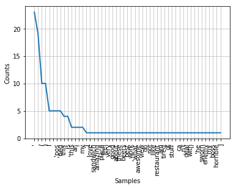

```python
fdist.plot()
```

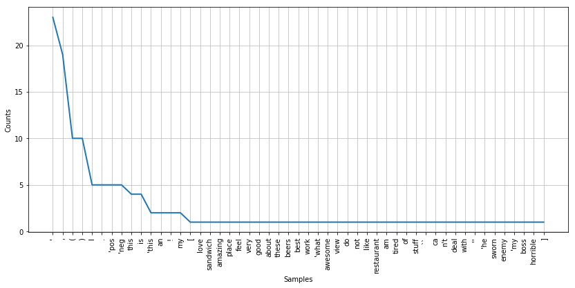

```python
plt.figure(figsize=(14,6))
fdist.plot()
```

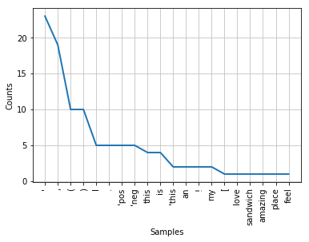

```python
fdist.plot(20)
```

You notice that some words/characters (e.g., is, i, this, an, a, the) are useless. These are called **stopwords** and they should be removed in real-world analysis.

```python
# If your data is already in string format (inside quotations), then just do this

data = "I love this sandwich !!! this is an amazing place !!! I feel very good about these beers. this is my best work???"

#tokenization = breaking into words
tokens = word_tokenize(data)
print(tokens)

fdist = FreqDist(tokens)
fdist
```

```
['I', 'love', 'this', 'sandwich', '!', '!', '!', 'this', 'is', 'an', 'amazing', 'place', '!', '!', '!', 'I', 'feel', 'very', 'good', 'about', 'these', 'beers', '.', 'this', 'is', 'my', 'best', 'work', '?', '?', '?']
```

```
FreqDist({'!': 6, 'this': 3, '?': 3, 'I': 2, 'is': 2, 'love': 1, 'sandwich': 1, 'an': 1, 'amazing': 1, 'place': 1, ...})
```

```python
# copy and paste the texts of an article from CNN and perform word frequency.
# for a long text, use triple quotes

data = '''   That publication of documents that had been shared with defense attorneys, but not made public in the ongoing case, was yet another disinformation campaign from Russia -- this time aimed at discrediting Mueller's investigation, federal prosecutors wrote in the filing Wednesday.
"Certain non-sensitive discovery materials in the defense's possession appear to have been altered and disseminated as part of a disinformation campaign aimed (apparently) at discrediting ongoing investigations into Russian interference in the U.S. political system," prosecutors wrote.  '''
```

```python
# show the word frequenc chart

#tokenization = breaking into words
tokens = word_tokenize(data)

fdist = FreqDist(tokens)
fdist
```

```
FreqDist({',': 4, 'in': 4, 'the': 4, 'of': 2, 'been': 2, 'defense': 2, 'ongoing': 2, 'disinformation': 2, 'campaign': 2, 'aimed': 2, ...})
```

# What if you have questions on Python coding?

The best option is **Stackoverflow http://stackoverflow.com/**: It is most likely you will find the question you're asking and the solution for that. For example, your question is **how to remove stopwords from your dataset before word frequency analysis**. Then,

- go to http://stackoverflow.com/
- search the following terms "nltk remove stopwords". this will return this page http://stackoverflow.com/search?q=nltk+remove+stopwords
- I would open one solution page http://stackoverflow.com/questions/38274356/removing-stopwords-using-nltk-in-python You will see many different solutions suggested by people. **Try the first answer from the list**. For example, one suggests: english_stopwords = stopwords.words('english') # get english stop words
- simply adapt the suggested code in your ipython notebook

```python
import nltk
nltk.download('stopwords')
```

```
True
```

```python
from nltk.corpus import stopwords
stopwords.words('english')
```

```
['i',
 'me',
 'my',
 'myself',
 'we',
 'our',
 'ours',
 'ourselves',
 'you',
 "you're",
 "you've",
 "you'll",
 "you'd",
 'your',
 'yours',
 'yourself',
 'yourselves',
 'he',
 'him',
 'his',
 'himself',
 'she',
 "she's",
 'her',
 'hers',
 'herself',
 'it',
 "it's",
 'its',
 'itself',
 'they',
 'them',
 'their',
 'theirs',
 'themselves',
 'what',
 'which',
 'who',
 'whom',
 'this',
```

[output cut: 124 more lines]

```
 "mustn't",
 'needn',
 "needn't",
 'shan',
 "shan't",
 'shouldn',
 "shouldn't",
 'wasn',
 "wasn't",
 'weren',
 "weren't",
 'won',
 "won't",
 'wouldn',
 "wouldn't"]
```

```python
data = "I love this sandwich !!! this is an amazing place !!! I feel very good about these beers. this is my best work???"

#import python function to remove stopwords (this is part of NLTK)
from nltk.corpus import stopwords

english_stopwords = stopwords.words('english')    # get english stop words

#tokenization = breaking into words
tokens = word_tokenize(data)
print(tokens)

# this line is important. First, every word is coverted to lowercase (w.lower()) and then remove all stop words
content = [w.lower() for w in tokens if w.lower() not in english_stopwords]
print(content)

fdist = FreqDist(content)
fdist
```

```
['I', 'love', 'this', 'sandwich', '!', '!', '!', 'this', 'is', 'an', 'amazing', 'place', '!', '!', '!', 'I', 'feel', 'very', 'good', 'about', 'these', 'beers', '.', 'this', 'is', 'my', 'best', 'work', '?', '?', '?']
['love', 'sandwich', '!', '!', '!', 'amazing', 'place', '!', '!', '!', 'feel', 'good', 'beers', '.', 'best', 'work', '?', '?', '?']
```

```
FreqDist({'!': 6, '?': 3, 'love': 1, 'sandwich': 1, 'amazing': 1, 'place': 1, 'feel': 1, 'good': 1, 'beers': 1, '.': 1, ...})
```

stopwords such as "is" and "an" were removed.

However, there are still non-alphabetical letters. You need to remove them as well.

Now, you should go to Stackover and search "python remove non-alphabetical" http://stackoverflow.com/search?q=python+remove+non-alphabetical. This solution http://stackoverflow.com/questions/26323162/python-remove-non-alphabetical-words looks promising to me. Also view the table ("some word comparison operators") below.

Some Word Comparison Operators Function Meaning s.startswith(t) test if s starts with t s.endswith(t) test if s ends with t t in s test if t is contained inside s s.islower() test if all cased characters in s are lowercase s.isupper() test if all cased characters in s are uppercase s.isalpha() test if all characters in s are alphabetic s.isalnum() test if all characters in s are alphanumeric s.isdigit() test if all characters in s are digits s.istitle() test if s is titlecased (all words in s have have initial capitals) http://www.nltk.org/book_1ed/ch01.html

```python
# first, remove non-alphabetical letters and stopwords and then perform word frequency analysis

data = " I ate 100 sandwiches !!! this is an amazing place !!! I feel very good about these beers. Stop by at 10:30"

#tokenization = breaking into words
tokens = word_tokenize(data)
print(tokens)

# this line is important. First, every word is coverted to lowercase (w.lower()) and then remove all stop words
content = [w for w in tokens if w.lower() not in english_stopwords]
print(content)

# remove non-alphabetical letters
cleaned_content = [w for w in content if w.isalpha()]

fdist = FreqDist(cleaned_content)
fdist
```

```
['I', 'ate', '100', 'sandwiches', '!', '!', '!', 'this', 'is', 'an', 'amazing', 'place', '!', '!', '!', 'I', 'feel', 'very', 'good', 'about', 'these', 'beers', '.', 'Stop', 'by', 'at', '10:30']
['ate', '100', 'sandwiches', '!', '!', '!', 'amazing', 'place', '!', '!', '!', 'feel', 'good', 'beers', '.', 'Stop', '10:30']
```

```
FreqDist({'ate': 1, 'sandwiches': 1, 'amazing': 1, 'place': 1, 'feel': 1, 'good': 1, 'beers': 1, 'Stop': 1})
```

```python
# now it is your turn. select numbers only and count how many numbers in the data

data = " I ate 100 sandwiches and 200 more !!! this is an amazing place !!! I feel very good about these beers. How about 50 more?"

#tokenization = breaking into words
tokens = word_tokenize(data)

cleaned_content = [w for w in tokens if w.isdigit()]

fdist = FreqDist(cleaned_content)
fdist
```

```
FreqDist({'100': 1, '200': 1, '50': 1})
```

# How to improve your IPython Notebook

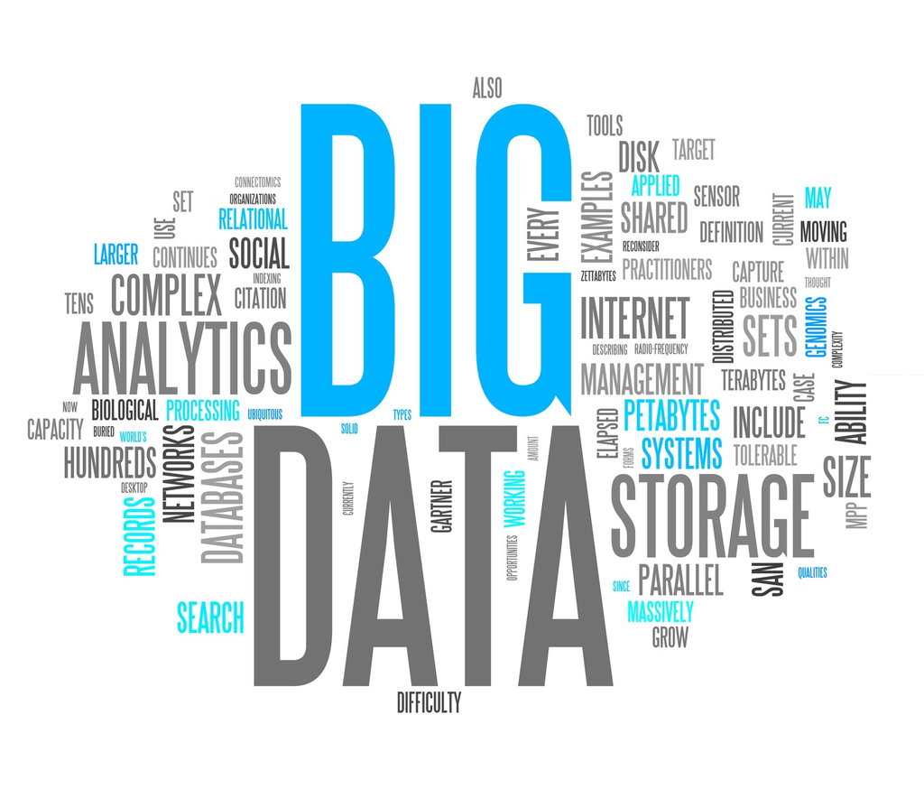

```python
# Include images in ipython notebook
from IPython.display import Image
Image("data/bigdata.png")
```

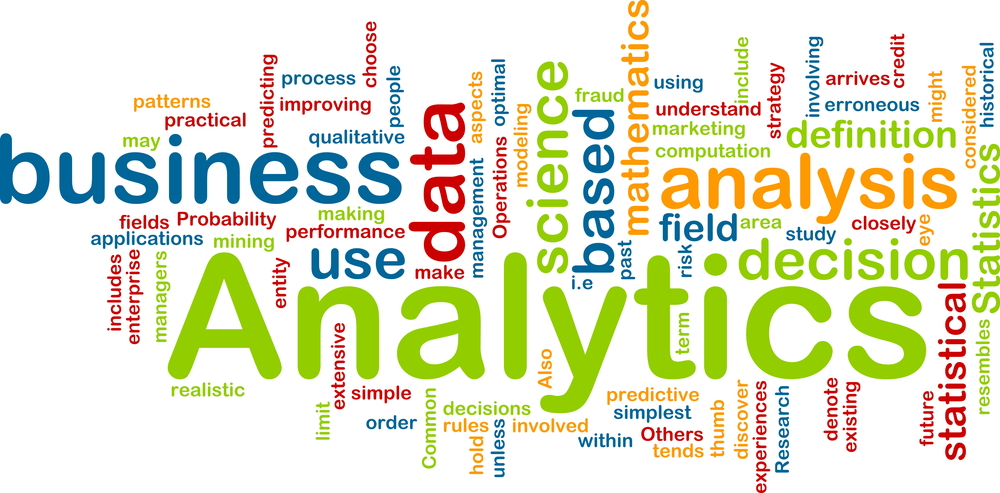

```python
# include bigdata1.png here

from IPython.display import Image
Image("data/bigdata1.jpg")
```

```python
# include web image
from IPython.display import Image
from IPython.core.display import HTML
Image(url= "http://ipython.org/_static/sloangrant/9_home_fperez_prof_grants_1207-sloan-ipython_proposal_fig_ipython-notebook-specgram.png")
```

[figure not shown]

```python
# include another web image

from IPython.display import Image
from IPython.core.display import HTML
Image(url= "http://visualwebripper.com/images/data_structure2.png")
```

[figure not shown]

```python
# You can include Youtube video in Ipython notebook
from IPython.display import YouTubeVideo
YouTubeVideo('zuQPmleaFrc')
#please ask questions!!!
```

[video not shown]

```python
# include a (funny) Youtube video

from IPython.display import YouTubeVideo
YouTubeVideo('JlCC8e_Uk2o')
```

[video not shown]

# How to Use Markdown effectively for Reporting

IPython notebooks are like web pages so you can use Markdown effectively for presenting your codes, results, and data visualization. More information can be found http://nestacms.com/docs/creating-content/markdown-cheat-sheet

# Brian Kassin

"On my honor, as a student, I have neither given nor received unauthorized aid on this academic work."

# For HW Submission¶

- Name this ipython notebook as **yourlastname_firstinitial_HW_pythonbootcamp_socialmedianalytics_webmining**
- Download this file as html (Go to **File / Download / As Html**)
- Submit it to Canvas